# Single Cell Exercise: Integrating single cell data

## Introduction

In this exercise notebook, we will practice integrating multiple scRNA-seq experiments.

The data we will be using comes from a set of experiments by [Muraro *et al.* (2016)](https://doi.org/10.1016/j.cels.2016.09.002) examining the human pancreas. Previous work on pancreatic gene expression had tended focus bulk preparations of whole islets. This approach not only obscured the variation among cell types that make up the islets, but also excluded pancreatic cells outside the islets that have important functions in processes like digestion.

Unlike much of the data we have worked with, this experiment did not use the 10x protocol, but rather a protocol called `CEL-Seq2` ([Hashimshony *et al.* 2016](https://doi.org/10.1186/s13059-016-0938-8)). In this protocol, cells are first sorted into individual wells, where transcripts are reverse-transcribed using a poly-T primer and tagged with a well/cell-specific barcode. These cDNA sequences are then pooled and amplified through *in vitro* transcription, then reverse transcribed again with random primers to create cDNA for sequencing. Since the initial step of this protocol works by capturing poly-A RNA, this is, like the 10x data, a tag-based system that will not result in full-length transcripts. The cell types were labeled by applying a clustering algorithm and then examining the expression of known markers among the clusters.

We have prepared separate SingleCellExperiment (SCE) objects with the data from each donor. There are four donors in this data set, one female (`D30`) and three male. Before we move on to more detailed analysis, we might first want to examine the extent to which the donor affects the overall patterns of gene expression variation. For example, if we perform clustering on the merged data, will we see clusters of cells that correspond to donors or cell types? If we do see a donor effect, can we mitigate that by applying an integration algorithm?

## Set up packages and paths

As usual, we will begin by loading some of packages that we will be using frequently.

Use the chunk below to load the `SingleCellExperiment` and `ggplot2` packages.

````r
```{r setup, solution = TRUE}
````

[output not shown]

Next, we want to be sure that our results here are reproducible, so set a random number seed in the next chunk:

```r
# Set a seed
set.seed(10389)
```

All the files that we will need are in the `data/pancreas/processed` subdirectory, so we will create a variable named `input_dir` to hold that path:

```r
input_dir <- file.path("data", "pancreas", "processed")
```

At the end of this notebook, we will save our results as a new SCE object, and we don’t want it to get mixed up with those input files, so we will create another variable named `output_dir` to store the output path (suggested path: `data/pancreas/integrated`) Make sure that directory actually exists, and create it if it doesn’t!

```r
# Define a directory to save the integrated SCE object
output_dir <- file.path("data,", "pancreas", "integrated")
# Create the output directory if it doesn't exist
fs::dir_create(output_dir)
```

## Read in files

With those paths defined, we can now read in the data. But first, let’s look to see what the data files are by listing the contents of the input directory:

```r
dir(input_dir)
```

```
[1] "D28_sce.rds" "D29_sce.rds" "D30_sce.rds" "D31_sce.rds"
```

Each of these files contains an SCE, and the files are labeled by donor (with an `_sce.rds` suffix). We’ll want to keep track of that, so we’ll start by creating a variable named `donors` which contains just the donor ids.

```r
donors <- c("D28", "D29", "D30", "D31")
```

We’ll want to transform this vector of ids into a vector of paths for the files we want to read in. We can do this using a combination of the `file.path()` function that we have been using and either `glue::glue()` or `paste0()`.

Note that all of these functions are vectorized, so when we give them an input that is a vector like `donors`, they will produce a vector of the same length.

Use the chunk below to make a `paths` vector that contains the paths that we will need.

```r
# create `paths` vector of input files
paths <- file.path(
  input_dir, # provide start of file path string
  glue::glue("{donors}_sce.rds") # provide vector with donor IDs
)

paths
```

```
[1] "data/pancreas/processed/D28_sce.rds" "data/pancreas/processed/D29_sce.rds" "data/pancreas/processed/D30_sce.rds"
[4] "data/pancreas/processed/D31_sce.rds"
```

For convenience later, we will want to make that vector of paths into a “named” vector, where each position is labeled with the donor id that the path refers to. We can do that with the `names()` function as shown below:

```r
# Set `paths` vector names
names(paths) <- donors
# Look at the result
paths
```

```
                                  D28                                   D29                                   D30                                   D31
"data/pancreas/processed/D28_sce.rds" "data/pancreas/processed/D29_sce.rds" "data/pancreas/processed/D30_sce.rds" "data/pancreas/processed/D31_sce.rds"
```

With that `paths` vector all set, we can now use `purrr::map()` to read in all of the input files, storing each object as elements of a list. The individual elements will retain the names we set in the vector, which will be very convenient for keeping track of everything! Store the list of SCE objects in a variable named `sce_list`.

```r
# Read SCE files with purrr
sce_list <- paths |>
  purrr::map(readr::read_rds)

sce_list
```

```
$D28
class: SingleCellExperiment
dim: 16940 333
metadata(0):
assays(2): counts logcounts
rownames(16940): ENSG00000268895 ENSG00000121410 ... ENSG00000159840 ENSG00000074755
rowData names(3): symbol chr ensembl
colnames(333): 1_1 1_2 ... 8_88 8_90
colData names(6): label plate ... detected total
reducedDimNames(2): PCA UMAP
mainExpName: endogenous
altExpNames(0):

$D29
class: SingleCellExperiment
dim: 16940 601
metadata(0):
assays(2): counts logcounts
rownames(16940): ENSG00000268895 ENSG00000121410 ... ENSG00000159840 ENSG00000074755
rowData names(3): symbol chr ensembl
colnames(601): 1_1 1_2 ... 8_91 8_94
colData names(6): label plate ... detected total
reducedDimNames(2): PCA UMAP
mainExpName: endogenous
altExpNames(0):

$D30
class: SingleCellExperiment
dim: 16940 676
metadata(0):
assays(2): counts logcounts
rownames(16940): ENSG00000268895 ENSG00000121410 ... ENSG00000159840 ENSG00000074755
rowData names(3): symbol chr ensembl
colnames(676): 1_1 1_4 ... 8_93 8_94
colData names(6): label plate ... detected total
reducedDimNames(2): PCA UMAP
mainExpName: endogenous
altExpNames(0):

$D31
class: SingleCellExperiment
dim: 16940 689
metadata(0):
assays(2): counts logcounts
rownames(16940): ENSG00000268895 ENSG00000121410 ... ENSG00000159840 ENSG00000074755
rowData names(3): symbol chr ensembl
colnames(689): 1_1 1_2 ... 8_93 8_94
colData names(6): label plate ... detected total
reducedDimNames(2): PCA UMAP
mainExpName: endogenous
altExpNames(0):
```

If everything has gone to plan, you should now be able to access an individual element of the list with a `$` and donor id, as shown below:

```r
sce_list$D28
```

```
class: SingleCellExperiment
dim: 16940 333
metadata(0):
assays(2): counts logcounts
rownames(16940): ENSG00000268895 ENSG00000121410 ... ENSG00000159840 ENSG00000074755
rowData names(3): symbol chr ensembl
colnames(333): 1_1 1_2 ... 8_88 8_90
colData names(6): label plate ... detected total
reducedDimNames(2): PCA UMAP
mainExpName: endogenous
altExpNames(0):
```

You might notice that the cells (`colnames`) in this dataset are not labeled by barcode sequence, but instead by a combination of plate and well numbers from the original cell sorting.

In the next chunk, have a look at what kinds of metadata we have for each cell and gene in one of the SCE objects. (We can assure you that in this case all of the objects have the same format, but you might want to check whether you believe us!) Recall that each cell is a column and each gene is a row in the SCE object.

```r
# View cell data
head(colData(sce_list[[1]]))
```

```
DataFrame with 6 rows and 6 columns
           label    plate sizeFactor       sum  detected     total
     <character> <factor>  <numeric> <numeric> <integer> <numeric>
1_1        alpha        1   0.549766   22195.5      5031   22195.5
1_2  endothelial        1   1.051240   30278.8      6004   30278.8
1_4         beta        1   1.144323   31978.8      6742   31978.8
1_5      unclear        1   0.493797   15103.2      4345   15103.2
1_13        duct        1   0.684839   22298.3      5470   22298.3
1_15       alpha        1   0.646755   25858.2      5460   25858.2
```

```r
# View gene data
head(rowData(sce_list[[1]]))
```

```
DataFrame with 6 rows and 3 columns
                     symbol         chr         ensembl
                <character> <character>     <character>
ENSG00000268895    A1BG-AS1       chr19 ENSG00000268895
ENSG00000121410        A1BG       chr19 ENSG00000121410
ENSG00000148584        A1CF       chr10 ENSG00000148584
ENSG00000245105     A2M-AS1       chr12 ENSG00000245105
ENSG00000166535       A2ML1       chr12 ENSG00000166535
ENSG00000175899         A2M       chr12 ENSG00000175899
```

## Merging SCE objects

Now that we have all of our SCE objects in a list, and we have looked at them to know what kinds of data and metadata they contain, we can start to merge them into a single object. You may have noticed that we don’t have any of the gene-specific statistics (such as mean expression across cells) in the `rowData` table that we had with the RMS data. That should make the merging quite a bit simpler!

In the chunk below, write a function named `format_sce` to perform the required reformatting of the SCE object. The function should take two arguments:

1. an SCE object
2. a donor id

The function should perform two actions:

- Add donor ids as a column of the SCE’s colData table (recall that you can add directly to this table with the `$` shortcut)
- Modify the SCE’s column names such that they contain both the original column name and the donor id to prevent having more than one column name with the same id after merging.

The function should then return the modified SCE object.

```r
# a function to reformat an SCE object with donor ids
format_sce <- function(
    sce,
    donor_id
) {
  # store the donor id in a new colData column
  sce$sample <- donor_id

  # Update the SCE object column names by prepending donor_id
  colnames(sce) <- glue::glue("{donor_id}-{colnames(sce)}")

  # Return the formatted SCE object
  return(sce)
}
```

You may want to test your function on a single element of `sce_list` to make sure it is doing what you expect.

```r
# test the function (not saving the result)
format_sce(sce_list$D28, "D28")
```

```
class: SingleCellExperiment
dim: 16940 333
metadata(0):
assays(2): counts logcounts
rownames(16940): ENSG00000268895 ENSG00000121410 ... ENSG00000159840 ENSG00000074755
rowData names(3): symbol chr ensembl
colnames(333): D28-1_1 D28-1_2 ... D28-8_88 D28-8_90
colData names(7): label plate ... total sample
reducedDimNames(2): PCA UMAP
mainExpName: endogenous
altExpNames(0):
```

If that works, producing the output we expect, we can now apply the function to all of the SCE objects in our list using `purrr`. In the instruction notebook, you may recall that we did this with `purrr::map2()`, giving it a list of the SCEs and a vector of sample ids to go through, passing each pair to a function. But `purrr` has another trick up its sleeve for when we have a named list, as we do here! If we want to use those names in our internal function, we can automatically have them passed in as the second argument by using `purrr::imap()` (the `i` stands for “index” here) without having to formally write it out. To use it, we will therefore only need two arguments for `purrr::imap()` – our `sce_list` and the `format_sce` function we just defined.

Give it a try in the chunk below, saving the result as a new list named `sce_list_formatted`.

```r
# apply formating function to `sce_list`
#  to create `sce_list_formatted`
sce_list_formatted <- purrr::imap(
  sce_list,
  format_sce
)
```

With all of our reformatting done, we can now merge the SCEs from our reformatted list into a single SCE object using `do.call()` and the `cbind` function. Save the result to a new object named `merged_sce`, and don’t forget to have a look at the result!

```r
# Merge SCE objects
merged_sce <- do.call(cbind, sce_list_formatted)

# Let's have a look!
merged_sce
```

```
class: SingleCellExperiment
dim: 16940 2299
metadata(0):
assays(2): counts logcounts
rownames(16940): ENSG00000268895 ENSG00000121410 ... ENSG00000159840 ENSG00000074755
rowData names(3): symbol chr ensembl
colnames(2299): D28-1_1 D28-1_2 ... D31-8_93 D31-8_94
colData names(7): label plate ... total sample
reducedDimNames(2): PCA UMAP
mainExpName: endogenous
altExpNames(0):
```

## Recalculating reduced dimensions

Merging the SCE objects also combined the reduced dimension matrices (PCA & UMAP) associated with each experiment (to one per reduced dimension type). However, the transformations that were applied to create those matrices from the input expression values are different for each experiment, so the values shouldn’t really be compared across experiments. To generate reduced dimension matrices that can be compared, we will recalculate the PCA and UMAP dimensions from the combined data set.

The first step is to identify a set of high variance genes to use as the basis for the PCA. In the chunk below, use the `scran::modelGeneVar()` and `scran::getTopHVGs()` functions to identify a set of genes with high biological variance. When creating the model with `scran::modelGeneVar()`, you will want to be sure to use the `block` argument to allow the model to account for the fact that there may be technical variation associated with the experimental design (the different donors, in this case). Store the high variance genes in a vector named `hv_genes`.

```r
num_genes <- 2000

# model biological variance in expression
gene_variance <- scran::modelGeneVar(merged_sce,
  # account for experimental variation
  block = merged_sce$sample
)

# save the high-variance genes
hv_genes <- scran::getTopHVGs(gene_variance,
                              n = num_genes)
```

With a set of high variance genes identified, we can now calculate a new PCA matrix. Use the `batchelor::multiBatchPCA()` function to perform this calculation with weighting by batch (donor). You will want to use the `subset.row` argument to restrict the PCA calculation to the high-variance genes that were identified above, and `preserve.single = TRUE` to save all of the results into a single matrix.

Save the resulting object to a variable named `merged_pca`.

```r
# calculate PCA from batched data
merged_pca <- batchelor::multiBatchPCA(
  merged_sce,
  subset.row = hv_genes,
  batch = merged_sce$sample,
  preserve.single = TRUE
)
```

We will now save the PCA matrix back into our `merged_sce` object. While we could make a new `reducedDim` slot for these data, there isn’t much reason to keep the old PCA matrix around. As discussed above, the different transformations from each donor mean that the results are not really comparable across the full set of experiments. So, we will save the `merged_pca` result into the base `"PCA"` slot, which will overwrite the previous `"PCA"` matrix. Recall that the output of `multiBatchPCA()` is a list, so we need to save just the first (and hopefully only) element of that list to the `reducedDim` PCA slot.

```r
# save multibatchPCA result to PCA slot
reducedDim(merged_sce, "PCA") <- merged_pca[[1]]
```

Now that the PCA is saved into our `merged_sce` object, we will use the hopefully familiar `scater::runUMAP()` function to calculate the UMAP dimensions and store them in the SCE object. As our PCA is stored in the `"PCA"` `reducedDim` slot, we will similarly store the new UMAP in the default `"UMAP"` slot.

```r
# calculate UMAP from PCA
merged_sce <- scater::runUMAP(
  merged_sce
)
```

Now we can use `scater::plotReducedDim()` or `scater::plotUMAP()` to visualize our merged but uncorrected results. Use the chunk below to create a UMAP plot of the merged data, colored by donor.

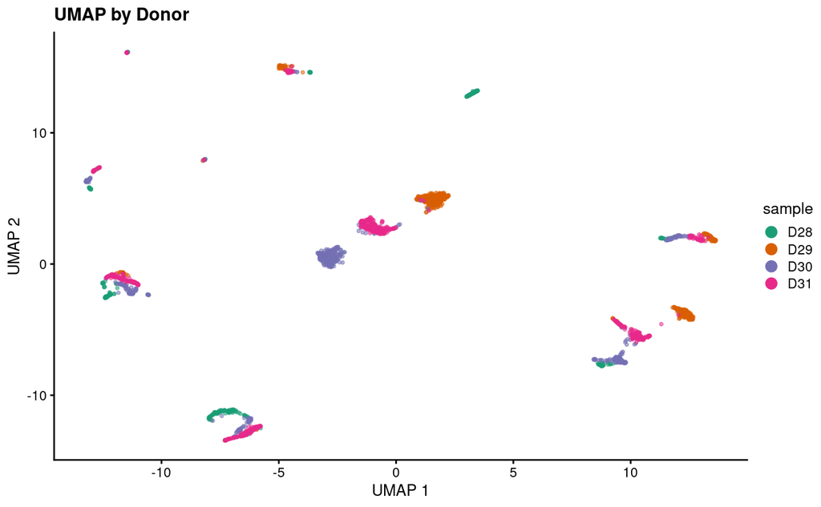

```r
# Plot UMAP colored by donor
scater::plotUMAP(
  merged_sce,
  color_by = "sample",
  # Some styling to help us see the points:
 point_size = 0.7,
 point_alpha = 0.5
) +
  # add more CVD-friendly color scale and legend title
  scale_color_brewer(palette = "Dark2", name = "sample") +
  guides(color = guide_legend(override.aes = list(size = 3, alpha = 1))) +
  ggtitle("UMAP by Donor")
```

What do you see in this plot? Does the plot suggest a strong effect of the donor on the overall expression patterns? You may recall the `D30` is the only female donor.

This dataset, conveniently, already has cell type labels, which you might have noticed while looking at the `colData` earlier, stored in the `label` column. Use the chunk below to plot the UMAP again, this time colored by cell type.

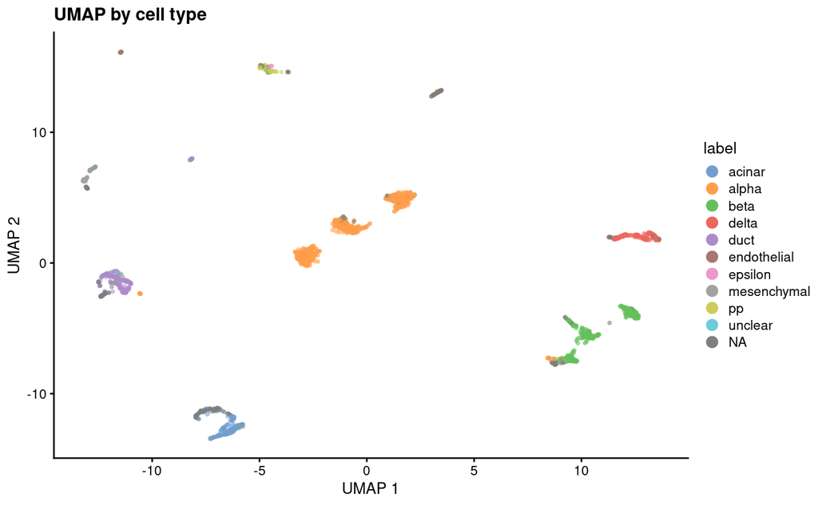

```r
# plot colored by cell types
scater::plotUMAP(
  merged_sce,
  color_by = "label",
  # Some styling to help us see the points:
 point_size = 0.7,
 point_alpha = 0.5
) +
  # add more CVD-friendly color scale and legend title
#  scale_color_brewer(palette = "Dark2", name = "sample") +
  guides(color = guide_legend(override.aes = list(size = 3, alpha = 1))) +
  ggtitle("UMAP by cell type")
```

### Clustering unintegrated data

Before we actually perform integration, let’s see what happens when we try to cluster these data without the batch correction that integration will provide. We will use the default clustering parameters for graph-based clustering to start (though you should feel free to modify the code below to add your your own tweaks to the clustering algorithm). Remember that the clustering results depend only the expression data that was used to generate the PC matrix – the cell labels are not used in the clustering algorithms.

```r
merged_sce$cluster_unintegrated <- scran::clusterCells(
  merged_sce,
  use.dimred = "PCA",
  BLUSPARAM = bluster::NNGraphParam()
)
```

Let’s make one more quick UMAP plot to see how this clustering algorithm performed on the unintegrated data:

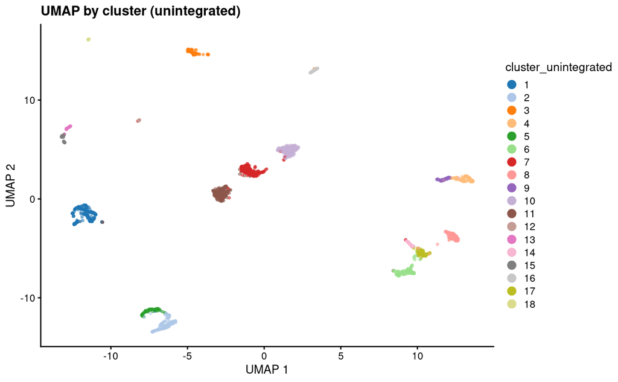

```r
# plot colored by clusters
scater::plotUMAP(
  merged_sce,
  color_by = "cluster_unintegrated",
  # Some styling to help us see the points:
 point_size = 0.7,
 point_alpha = 0.5
) +
  # add more CVD-friendly color scale and legend title
#  scale_color_brewer(palette = "Dark2", name = "sample") +
  guides(color = guide_legend(override.aes = list(size = 3, alpha = 1))) +
  ggtitle("UMAP by cluster (unintegrated)")
```

What seems to be the basis of the clustering that you see? Does it seem to be mainly driven by cell type, donor, or some combination of the two?

## Integrating with `fastMNN`

Now let’s see what happens with this dataset when we apply mutual nearest neighbor (MNN) integration. Use the `batchelor::fastMNN()` function to do this in the chunk below, saving the result as a new SCE object. Restrict the analysis to the highly variable genes we used for the PCA analysis above, using the same `subset.row` argument that we used before.

```r
# perform fastMNN analysis by donor
integrated_sce <- batchelor::fastMNN(
  merged_sce,
  batch = merged_sce$sample,
  subset.row = hv_genes
)
```

The integrated PCA matrix will be stored in the `"corrected"` `reducedDim` slot of your new SCE object. We’d rather have it stored in our `merged_sce` alongside all of the original data, so use the next chunk to save it into a `reducedDim` slot named `"fastMNN_PCA"`.

```r
# store integrated PCA in `merged_sce` object
reducedDim(merged_sce, "fastmnn_PCA") <- reducedDim(integrated_sce, "corrected")
```

Once you have stored the corrected PCA matrix as described, you should be able to run the chunk below to calculated a corresponding UMAP matrix, which will be stored as `"fastMNN_UMAP"`.

```r
# calculate UMAP from fastMNN results
merged_sce <- scater::runUMAP(
  merged_sce,
  dimred = "fastmnn_PCA",
  name = "fastmnn_UMAP"
)
```

The hard work is done; now it is time to see how it all looks!

In the chunk below, plot the `fastMNN_UMAP` colored by cell type (`label`).

[figure not shown]

```r
# UMAP plot colored by cell type label
scater::plotUMAP(merged_sce,
                 dimred = "fastmnn_UMAP",
                 color_by = "label",
                 point_size = 0.5,
                 point_alpha = 0.2) +
  # add more CVD-friendly color scale and legend title
  scale_color_brewer(palette = "Dark2", name = "label") +
  guides(color = guide_legend(override.aes = list(size = 3, alpha = 1))) +
  ggtitle("UMAP by sample (integrated)")
```

How does this plot compare to the previous (unintegrated) UMAP?

As we evaluate this, we also want to look at the UMAP plot colored by donor. Ideally, we would see that the donors are all mixed within each “blob” of cells.

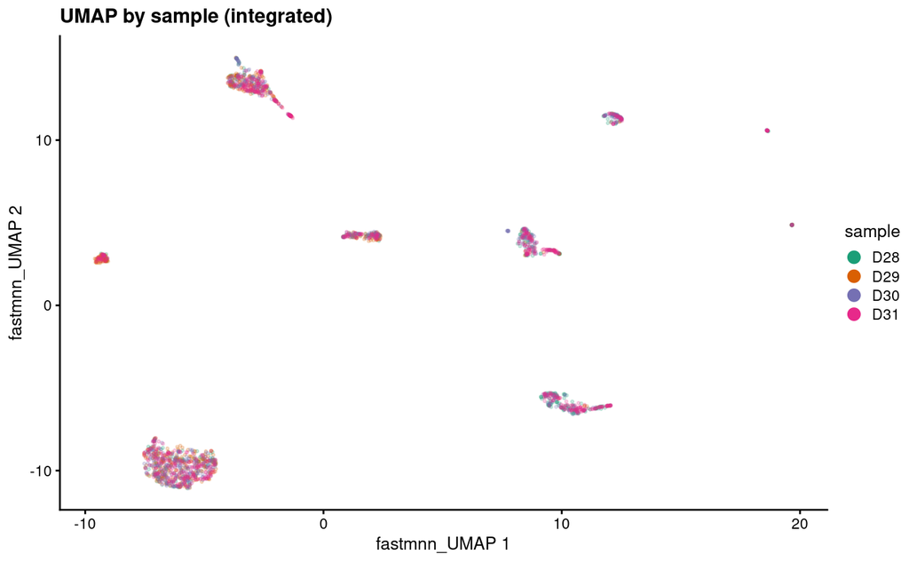

```r
# UMAP plot colored by donor
scater::plotUMAP(merged_sce,
                 dimred = "fastmnn_UMAP",
                 color_by = "sample",
                 point_size = 0.5,
                 point_alpha = 0.2) +
  # add more CVD-friendly color scale and legend title
  scale_color_brewer(palette = "Dark2", name = "sample") +
  guides(color = guide_legend(override.aes = list(size = 3, alpha = 1))) +
  ggtitle("UMAP by sample (integrated)")
```

It looks like there is probably some good overlap there, but now we have a different problem. The points are plotted in order by donor, so it is very hard to see what is going on with the donors that are plotted first!

Let’s do better! One remedy for this is to shuffle the columns in the SCE object – this won’t affect the data, but it will affect the order in which points are plotted, which *can sometimes* result in easier viewing.

```r
# create a random order for the cells
col_order <- sample(ncol(merged_sce))
# apply the reordering
shuffled_sce <- merged_sce[, col_order]
```

Now we can plot that `shuffled_sce` just as we did before, and see how it looks. Use the chunk below to do that!

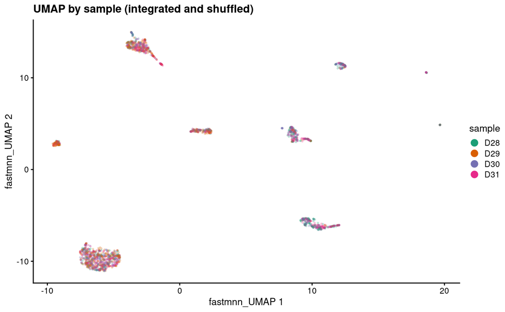

```r
# shuffled UMAP plot colored by donor
scater::plotUMAP(shuffled_sce,
                 dimred = "fastmnn_UMAP",
                 color_by = "sample",
                 point_size = 0.5,
                 point_alpha = 0.2) +
  # add more CVD-friendly color scale and legend title
  scale_color_brewer(palette = "Dark2", name = "sample") +
  guides(color = guide_legend(override.aes = list(size = 3, alpha = 1))) +
  ggtitle("UMAP by sample (integrated and shuffled)")
```

Are you satisfied with this integration result? Do the different cell types seem to be more uniformly mixed across donors? Are there any areas of particular concern that you might want to explore more?

### Clustering integrated data

Finally, let’s look at what happens to clustering when we use the integrated data. In the chunk below use the same clustering parameters that you used for the unintegrated data to cluster again, this time using the `fastMNN_PCA` as the input for the clustering algorithm. Then plot these clustering results on the integrated UMAP results to see how they align.

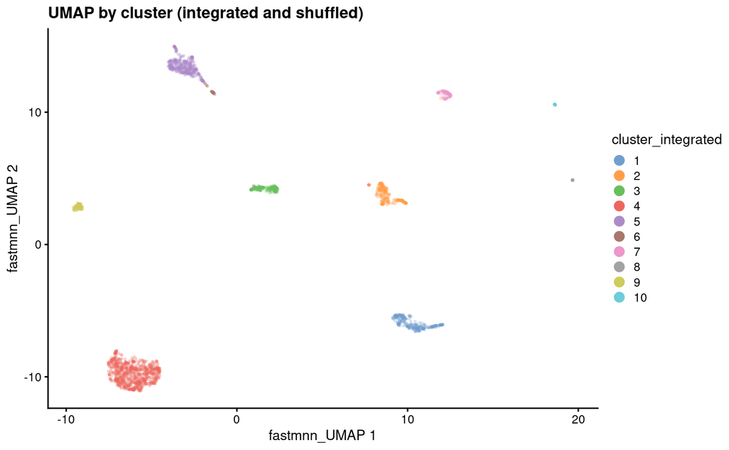

```r
# cluster using `fastMNN_PCA`
merged_sce$cluster_integrated <- scran::clusterCells(
  merged_sce,
  use.dimred = "fastmnn_PCA",
  BLUSPARAM = bluster::NNGraphParam()
)

# plot UMAP colored by integrated clusters
scater::plotUMAP(merged_sce,
                 dimred = "fastmnn_UMAP",
                 color_by = "cluster_integrated",
                 point_size = 0.5,
                 point_alpha = 0.2) +
# add more CVD-friendly color scale and legend title
#scale_color_brewer(palette = "Dark2", name = "Clusters") +
guides(color = guide_legend(override.aes = list(size = 3, alpha = 1))) +
ggtitle("UMAP by cluster (integrated and shuffled)")
```

How do the clusters inferred from the integrated data compare to what you saw earlier with unintegrated data? If the integration was successful, we might expect to see some differences between this plot and the plot of unintegrated clusters:

- Clusters should correspond more closely to cell types
- Donor effects should be less apparent in the clustering Does that seem to be the the case here?

## Integration metrics

The evaluation we have done so far of the integration quality has been quite qualitative. We’ve looked at some UMAPs and expressed whether the “vibes” were right. It might be nice to be a bit more quantitative, especially if we were going to be comparing different integration methods. The challenge with being quantitative is that we have to pick something to measure, and have some confidence that what we are measuring accurately reflects the properties we are seeking to optimize.

Generally speaking, our goal with integration is to remove technical variation while preserving biological information. In the case of purely technical replicates, where we have the same cells measured multiple times, we could try to make each cell line up exactly with its replicates, and this would be easy to measure. But of course we don’t have those! Every cell is its own biological sample, so the best we can hope for is that cells of the same type from replicate samples have similar corrected expression values (or reduced dimensions we calculate from those). But even that is a better scenario than what we usually have - the samples we would like to integrate are often from different tissue samples and/or different individuals. What is our quantitative expectation for how well individual cells should align in this case?

There are no easy answers here, which ends up meaning that there are many directions one could go to assess integration quality.

One common pattern is to calculate a metric that quantifies some aspect of clustering before and after integration. By looking at how the metric changes after integration, we can determine whether the integration has had desired effects or not. For example, did we reduce the extent of clustering by sample (technical variation) while preserving clustering by cell type (biological variation)?

A few methods are discussed in the friendly OSCA Book chapter on [Correction Diagnostics](http://bioconductor.org/books/3.19/OSCA.multisample/correction-diagnostics.html). One approach is to measure whether clusters after integration have consistent proportions of cells from each integrated sample. Another is to test whether the clustering pattern found in individual samples is preserved after integration (to check for over-correction).

One way to quantify changes in clustering is to use a measure like [adjusted Rand index (ARI)](http://bioconductor.org/books/3.19/OSCA.advanced/clustering-redux.html#adjusted-rand-index). This measure varies between 0 and 1, and describes how consistent cluster assignments are between two different methods. If we apply this to compare clusters *within a sample* before and after integration, we would expect to see good agreement, resulting in high ARI scores. By contrast, if we compare clustering *across samples*, we might expect to see that the clusters before integration are driven by between-sample variation (hopefully technical effects), whereas after integration the clusters are more determined by variation among cell types. This change would result in lower ARI scores.

One important result from the Luecken *et al.* study was that the different integration methods perform quite differently depending on the precise set of samples, with some more aggressively removing batch effects than others. It is also important to note that many of the datasets used for benchmarking integration do not include cancer cells, which may result in very different expectations for clustering and integration. One study that did examine cancer samples found that `fastMNN` seemed to do a good job of reducing technical variation while preserving expected biological signals ([Richards *et al.* 2021](https://doi.org/10.1101/2021.08.04.453579)). Ultimately, the best integration method and the best metrics to use will depend both on the samples you are exploring and the questions you are seeking to ask from the integrated data!